# Tractats de Pau i Gènere

Jaume Amorós

20 de noviembre de 2019

## Descripció

Aquest document presenta un enfocament per fer una presentació de les dades de Tractats de Pau per mitja de representacions gràfiques. Es treballa amb dades del repositori peaceagreements.org[www.peaceagreements.org], generat i mantingut per l’equip de Law School de la University of Edinburgh.

Es un docuemnt generat amb un MarkDown que inclou chunks de codi d’R que permet fer l’exploració, depuració i analisi (visualització) de les dades).

En aquest document s’ha optat per avaluar els acords de pau en clau de gènere. Per a fer-ho inclourem les variables relatives a gènere en el conjutn de dades que treballarem. La variable principal es GeWom que indica si en el tractat de Pau signat s’inclou alguna referencia explicita a les dones o al gènere.

```r
# Seleccionem el fitxer
fitxer <- "pax_data_1789_agreements_19-11-19.csv"

# Importem tot el conjunt de dades
data_brut <- read.table(fitxer, sep = ',', quote = '"', header = TRUE, stringsAsFactors = FALSE)
dim(data_brut)
```

```
## [1] 1789  266
```

## Presentació de les dades

En el conjunt de dades total podem veure que hi ha 1789 registres i 266 columnes. Cada columna correspon a una variable a analitzar i cada registre a un tractat de Pau. En el conjunt de dades hi ha moltes variables que per l’objectiu d’aquest exercici no ens interessen. Ens quedarem únicament amb les dades geografiques, la data i les variables relaconades amb el gènere. Les variables de gènere estan codificades de manera que les dues priemres lletres sempre son “Ge”.

```r
# Seleccionem la regió, la data i les variables de Gènere
genderVar <- grep("Ge", colnames(data_brut), value = TRUE)
columnes  <- c("ï..Con", "Reg", "Dat", genderVar)
data      <- data_brut[, columnes]
dim(data)
```

```
## [1] 1789   19
```

En el nou conjunt de dades tenim els mateixos registres però ens hem quedat únicament amb 19 variables.

A continuació transformarem la data en format de data i n’extraurem l’any:

```r
# Transformem la data en format data i extraiem l'any en una variable nova
data$Dat  <- as.Date(data$Dat)
data$Year <- year(data$Dat)
```

## Exploració de les dades

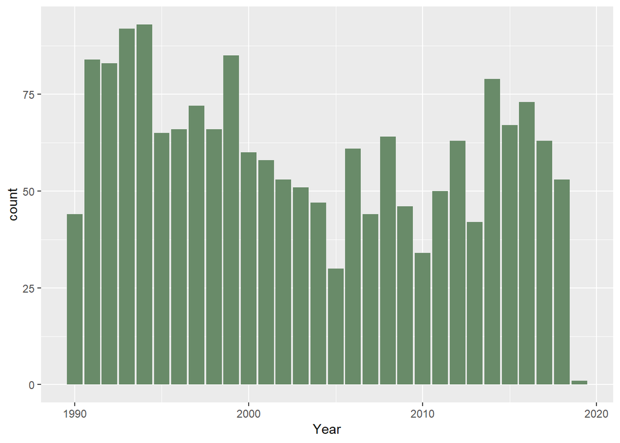

FALSE

```r
# Transformem la data en format data i extraiem l'any en una variable nova
ggplot(data) +
  geom_bar(aes(Year), fill = "darkseagreen4")
```

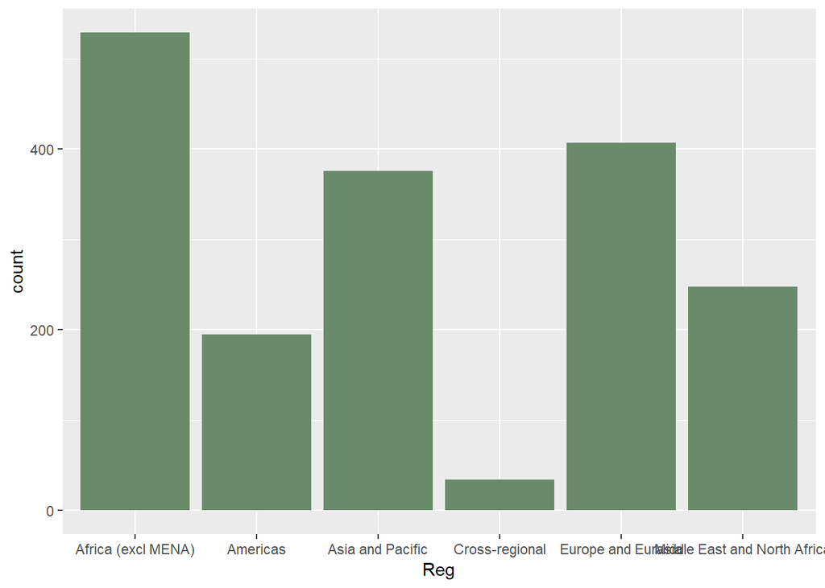

FALSE

```r
ggplot(data) +
  geom_bar(aes(Reg), fill = "darkseagreen4")
```

Podem veure que en la segona meitat del periode de dades analitzat el nombre de tractats de pau signats es inferior. La majoria de conflictes es concentren a Africa. El nombre de conflictes a Europa i Asia també es considerable.

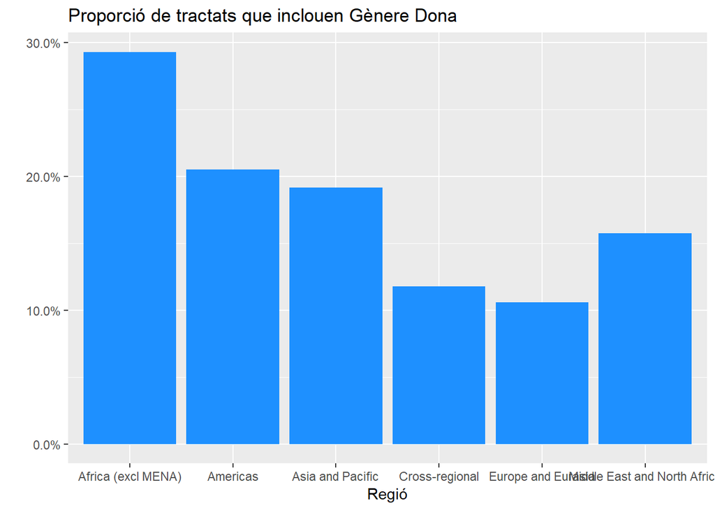

FALSE

```r
# Creem un conjunt de dades per regió que ens indiqui la proporció de tractats que inclouen la paraula dona
d_RegGeWom <- data %>%
  group_by(Reg) %>%
  summarise(GeWom = mean(GeWom),
            GeSo = mean(GeSo),
            Count = n()) %>%
  ungroup()

ggplot(d_RegGeWom, aes(x = Reg)) +
  geom_col(aes(y = GeWom), fill = "dodgerblue") +
  scale_y_continuous(labels=scales::percent) +
  labs(title = "Proporció de tractats que inclouen Gènere Dona",
       x = "Regió", y = "")
```

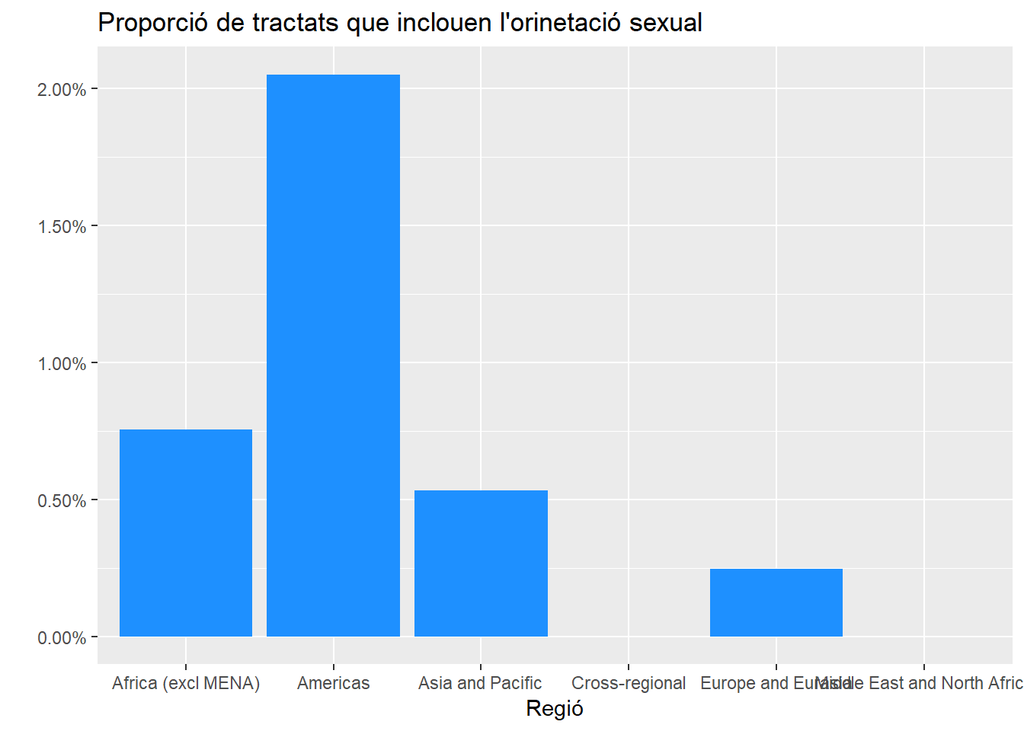

FALSE

```r
ggplot(d_RegGeWom, aes(x = Reg)) +
  geom_col(aes(y = GeSo), fill = "dodgerblue") +
  scale_y_continuous(labels=scales::percent) +
  labs(title = "Proporció de tractats que inclouen l'orinetació sexual",
       x = "Regió", y = "")
```

El percentatge de tractats que inclouen explicitament conceptes de dòna i gènere es considerable. A Africa son vora el 30%. A Europa no es menciona massa les dones explicitament en els tractats.

La orientació sexual no apareix pràcticament a cap tractat.

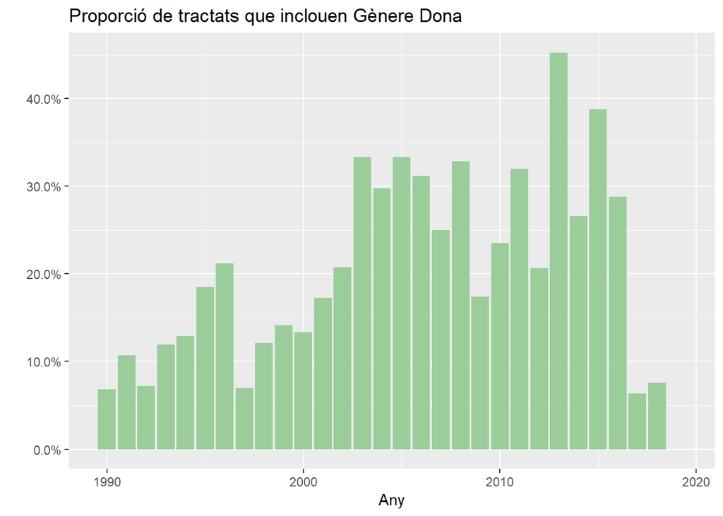

FALSE

```r
# Creem un conjunt de dades temporals que ens indiqui la proporció de tractats que inclouen la paraula dona
d_YeargGeWom <- data %>%
  group_by(Year) %>%
  summarise(GeWom = mean(GeWom),
            GeSo = mean(GeSo),
            Count = n()) %>%
  ungroup()

ggplot(d_YeargGeWom, aes(x = Year)) +
  geom_col(aes(y = GeWom), fill = "darkseagreen3") +
  scale_y_continuous(labels=scales::percent) +
  labs(title = "Proporció de tractats que inclouen Gènere Dona",
       x = "Any", y = "")
```

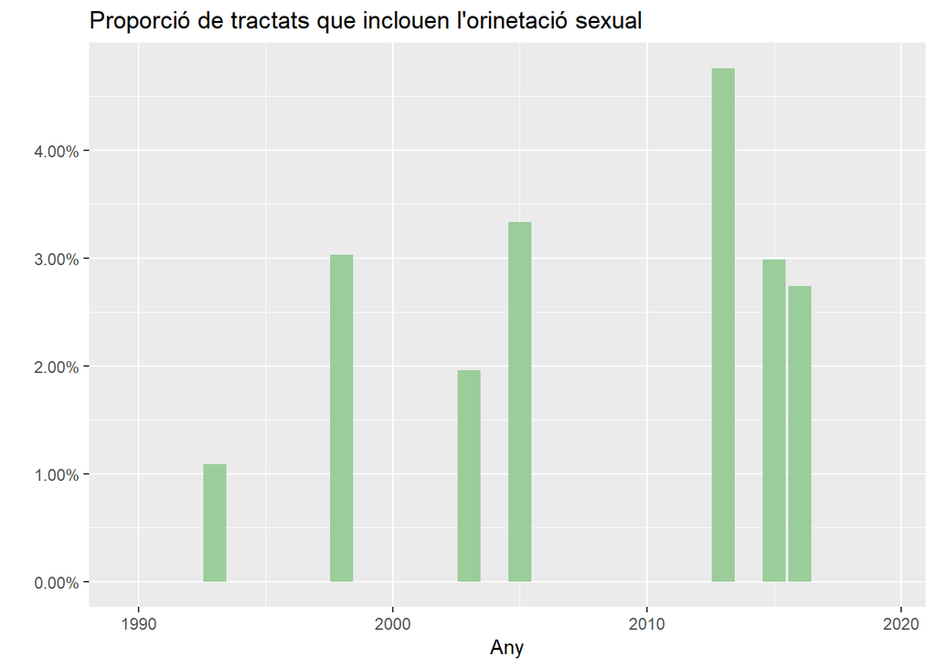

FALSE

```r
ggplot(d_YeargGeWom, aes(x = Year)) +
  geom_col(aes(y = GeSo), fill = "darkseagreen3") +
  scale_y_continuous(labels=scales::percent) +
  labs(title = "Proporció de tractats que inclouen l'orinetació sexual",
       x = "Any", y = "")
```

En l’evolució temporal, també podem veure com cada cop és més freqüent les referencies directes al Gènere en els tractats de Pau. També sembla que les referencies a orientació sexual tendeixen a ser més recents. Però son tan poques que seria dificil fer-ne un analisi.